# Web Scraping

MATH-7360 Data Analysis

Dr. Xiang Ji @ Tulane University

Oct 25, 2021

## Announcement

- More HW2 questions (thank you for bringing them up)
  - Q1: “I’m not quite sure what the difference is between”Weekly case" and “Weekly total case”."
    - A: They mean the same thing. `weekly total case = weekly case = sum of new cases in a given week`.
  - Q4: “I have the cumulative percent positivity rates for the individual weeks required in Problem 4. Do I need to plot the cumulative positivity rate for the whole week (over 7 days, which would be one number I guess) on the map of Louisiana?”
    - A: Please calculate the cumulative positive rates by using week as the unit. You want to plot them on a map. Your plot should have the shape of Louisiana’s map with color coded rates for each parish.
  - Q4: “I have some difficulties when working on Q4, by searching Google, I find the method to plot the dot for each city on the map of LA, this can be done by using function geocode() in “ggmap” package, but this requires an API key, I’m wondering if this is the feasible way to get the geocode for each Parish. Would you please give me some hint or reference? Thank you so much!"
    - A: I was able to use “sf”, “usmap” and “map” libraries to work out Q4. I didn’t need any API keys. I used FIPS code for parish.

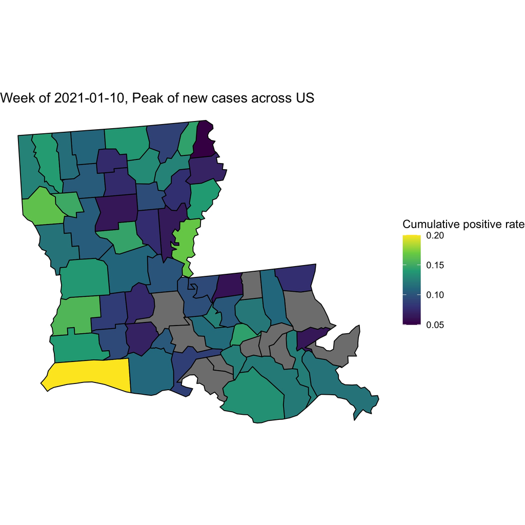

## Acknowledgement

Dr. Hua Zhou’s [slides](https://ucla-biostat203b-2020winter.github.io/slides/10-scraping/scraping.html)

Josh McCrain’s [RSelenium tutorial](http://joshuamccrain.com/tutorials/web_scraping_R_selenium.html)

HTML Introduction [from GeeksforGeeks](https://www.geeksforgeeks.org/html-introduction/)

Getting started with HTML [MDN Web Docs](https://developer.mozilla.org/en-US/docs/Learn/HTML/Introduction_to_HTML/Getting_started)

Load tidyverse and other packages for this lecture:

```r
library("tidyverse")
library("rvest")
```

## HTML introduction

We cover some survival amount of instroduction of HTML format first.

**HTML** stands for HyperText Markup Language.

- used to design web pages using a markup language
- combination of Hypertext and Markup language
  - Hypertext defines the link between the web pages
  - A markup language is used to define the text document within tag which defines the structure of web pages.

### Elements and Tags

- HTML uses predefined **tags** and **elements** which tell the browser how to properly display the content.
- Remember to include closing tags. If omitted, the browser applies the effect of the opening tag until the end of the page.

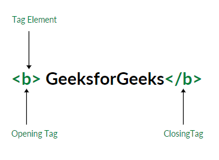

### Attributes

An attribute should have:

- A space between it and the element name. (For an element with more than one attribute, the attributes should be separated by spaces too.)
- The attribute name, followed by an equal sign.
- An attribute value, wrapped with opening and closing quote marks.

### Anchors

Another example of an element is `<a>`. This stands for *anchor*. An anchor can make the text it encloses into a **hyperlink**. Anchors can take a number of attributes, but several are as follows:

- `href`: This attribute’s value specifies the web address for the link. For example: `href="https://www.mozilla.org/"`.
- `title`: The `title` attribute specifies extra information about the link, such as a description of the page that is being linked to. For example, `title="The Mozilla homepage"`. This appears as a tooltip when a cursor hovers over the element.
- `target`: The `target` attribute specifies the browsing context used to display the link. For example, `target="_blank"` will display the link in a new tab. If you want to display the linked content in the current tab, just omit this attribute.

### HTML page structure

- The basic structure of an HTML page is laid out below.
- It contains the essential building-block elements upon which all web pages are created.
  - doctype declaration
  - HTML
  - head
  - title
  - body elements

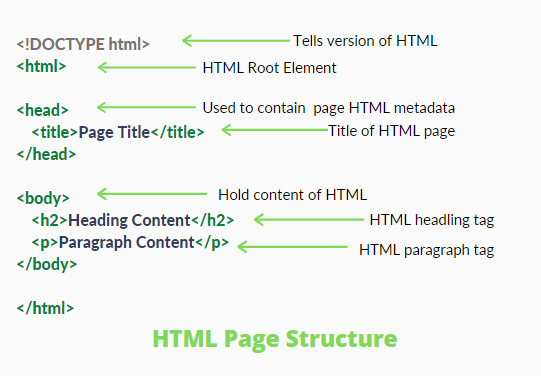

### HTML comments

To write an HTML comment, wrap it in the special markers `<!-- and -->`. For example:

> `<p>I'm not inside a comment</p>`

> `<!-- <p>I am!</p> -->`

generates:

I’m not inside a comment

## Web scraping

There is a wealth of data on internet. How to scrape them and analyze them?

## rvest

rvest is an R package written by Hadley Wickham which makes web scraping easy.

## Example: Scraping from webpage

- We follow instructions in a [Blog by SAURAV KAUSHIK](https://www.analyticsvidhya.com/blog/2017/03/beginners-guide-on-web-scraping-in-r-using-rvest-with-hands-on-knowledge/) to find the most popular feature films of 2019.
- Install the [SelectorGadget](https://selectorgadget.com/) extension for Chrome.
- The 100 most popular feature films released in 2019 can be accessed at page https://www.imdb.com/search/title?count=100&release_date=2019,2019&title_type=feature.

  ```r
  #Loading the rvest and tidyverse package
  #Specifying the url for desired website to be scraped
  url <- "http://www.imdb.com/search/title?count=100&release_date=2019,2019&title_type=feature"
  #Reading the HTML code from the website
  (webpage <- read_html(url))
  ```

  ```
  ## {html_document}
  ## <html xmlns:og="http://ogp.me/ns#" xmlns:fb="http://www.facebook.com/2008/fbml">
  ## [1] <head>\n<meta http-equiv="Content-Type" content="text/html; charset=UTF-8 ...
  ## [2] <body id="styleguide-v2" class="fixed">\n            <img height="1" widt ...
  ```

- Suppose we want to scrape following 11 features from this page:
  - Rank
  - Title
  - Description
  - Runtime
  - Genre
  - Rating
  - Metascore
  - Votes
  - Gross_Eerning_in_Mil
  - Director
  - Actor

[figure not shown]

### Rank

- Use SelectorGadget to highlight the element we want to scrape

[figure not shown]

- Use the CSS selector to get the rankings

  ```r
  # Use CSS selectors to scrap the rankings section
  (rank_data_html <- html_nodes(webpage, '.text-primary'))
  ```

  ```
  ## {xml_nodeset (100)}
  ##  [1] <span class="lister-item-index unbold text-primary">1.</span>
  ##  [2] <span class="lister-item-index unbold text-primary">2.</span>
  ##  [3] <span class="lister-item-index unbold text-primary">3.</span>
  ##  [4] <span class="lister-item-index unbold text-primary">4.</span>
  ##  [5] <span class="lister-item-index unbold text-primary">5.</span>
  ##  [6] <span class="lister-item-index unbold text-primary">6.</span>
  ##  [7] <span class="lister-item-index unbold text-primary">7.</span>
  ##  [8] <span class="lister-item-index unbold text-primary">8.</span>
  ##  [9] <span class="lister-item-index unbold text-primary">9.</span>
  ## [10] <span class="lister-item-index unbold text-primary">10.</span>
  ## [11] <span class="lister-item-index unbold text-primary">11.</span>
  ## [12] <span class="lister-item-index unbold text-primary">12.</span>
  ## [13] <span class="lister-item-index unbold text-primary">13.</span>
  ## [14] <span class="lister-item-index unbold text-primary">14.</span>
  ## [15] <span class="lister-item-index unbold text-primary">15.</span>
  ## [16] <span class="lister-item-index unbold text-primary">16.</span>
  ## [17] <span class="lister-item-index unbold text-primary">17.</span>
  ## [18] <span class="lister-item-index unbold text-primary">18.</span>
  ## [19] <span class="lister-item-index unbold text-primary">19.</span>
  ## [20] <span class="lister-item-index unbold text-primary">20.</span>
  ## ...
  ```

  ```r
  # (rank_data_html <- html_nodes(webpage, '.lister-item-content .text-primary'))
  # Convert the ranking data to text
  (rank_data <- html_text(rank_data_html))
  ```

  ```
  ##   [1] "1."   "2."   "3."   "4."   "5."   "6."   "7."   "8."   "9."   "10."
  ##  [11] "11."  "12."  "13."  "14."  "15."  "16."  "17."  "18."  "19."  "20."
  ##  [21] "21."  "22."  "23."  "24."  "25."  "26."  "27."  "28."  "29."  "30."
  ##  [31] "31."  "32."  "33."  "34."  "35."  "36."  "37."  "38."  "39."  "40."
  ##  [41] "41."  "42."  "43."  "44."  "45."  "46."  "47."  "48."  "49."  "50."
  ##  [51] "51."  "52."  "53."  "54."  "55."  "56."  "57."  "58."  "59."  "60."
  ##  [61] "61."  "62."  "63."  "64."  "65."  "66."  "67."  "68."  "69."  "70."
  ##  [71] "71."  "72."  "73."  "74."  "75."  "76."  "77."  "78."  "79."  "80."
  ##  [81] "81."  "82."  "83."  "84."  "85."  "86."  "87."  "88."  "89."  "90."
  ##  [91] "91."  "92."  "93."  "94."  "95."  "96."  "97."  "98."  "99."  "100."
  ```

  ```r
  # Turn into numerical values
  (rank_data <- as.integer(rank_data))
  ```

  ```
  ##   [1]   1   2   3   4   5   6   7   8   9  10  11  12  13  14  15  16  17  18
  ##  [19]  19  20  21  22  23  24  25  26  27  28  29  30  31  32  33  34  35  36
  ##  [37]  37  38  39  40  41  42  43  44  45  46  47  48  49  50  51  52  53  54
  ##  [55]  55  56  57  58  59  60  61  62  63  64  65  66  67  68  69  70  71  72
  ##  [73]  73  74  75  76  77  78  79  80  81  82  83  84  85  86  87  88  89  90
  ##  [91]  91  92  93  94  95  96  97  98  99 100
  ```

### Title

- Use SelectorGadget to find the CSS selector `.lister-item-header a`.
- [CSS selector reference](https://www.w3schools.com/cssref/css_selectors.asp)

  ```r
  # Using CSS selectors to scrap the title section
  (title_data_html <- html_nodes(webpage, '.lister-item-header a'))
  ```

  ```
  ## {xml_nodeset (100)}
  ##  [1] <a href="/title/tt8946378/?ref_=adv_li_tt">Knives Out</a>
  ##  [2] <a href="/title/tt6751668/?ref_=adv_li_tt">Parasite</a>
  ##  [3] <a href="/title/tt8772262/?ref_=adv_li_tt">Midsommar</a>
  ##  [4] <a href="/title/tt7286456/?ref_=adv_li_tt">Joker</a>
  ##  [5] <a href="/title/tt7131622/?ref_=adv_li_tt">Once Upon a Time... In Hollyw ...
  ##  [6] <a href="/title/tt1620981/?ref_=adv_li_tt">The Addams Family</a>
  ##  [7] <a href="/title/tt4154796/?ref_=adv_li_tt">Avengers: Endgame</a>
  ##  [8] <a href="/title/tt7984734/?ref_=adv_li_tt">The Lighthouse</a>
  ##  [9] <a href="/title/tt5606664/?ref_=adv_li_tt">Doctor Sleep</a>
  ## [10] <a href="/title/tt8579674/?ref_=adv_li_tt">1917</a>
  ## [11] <a href="/title/tt3281548/?ref_=adv_li_tt">Little Women</a>
  ## [12] <a href="/title/tt7349950/?ref_=adv_li_tt">It Chapter Two</a>
  ## [13] <a href="/title/tt7984766/?ref_=adv_li_tt">The King</a>
  ## [14] <a href="/title/tt8367814/?ref_=adv_li_tt">The Gentlemen</a>
  ## [15] <a href="/title/tt4154664/?ref_=adv_li_tt">Captain Marvel</a>
  ## [16] <a href="/title/tt7798634/?ref_=adv_li_tt">Ready or Not</a>
  ## [17] <a href="/title/tt2584384/?ref_=adv_li_tt">Jojo Rabbit</a>
  ## [18] <a href="/title/tt2527338/?ref_=adv_li_tt">Star Wars: The Rise Of Skywal ...
  ## [19] <a href="/title/tt6320628/?ref_=adv_li_tt">Spider-Man: Far from Home</a>
  ## [20] <a href="/title/tt4126476/?ref_=adv_li_tt">After</a>
  ## ...
  ```

  ```r
  # Converting the title data to text
  (title_data <- html_text(title_data_html))
  ```

  ```
  ##   [1] "Knives Out"
  ##   [2] "Parasite"
  ##   [3] "Midsommar"
  ##   [4] "Joker"
  ##   [5] "Once Upon a Time... In Hollywood"
  ##   [6] "The Addams Family"
  ##   [7] "Avengers: Endgame"
  ##   [8] "The Lighthouse"
  ##   [9] "Doctor Sleep"
  ##  [10] "1917"
  ##  [11] "Little Women"
  ##  [12] "It Chapter Two"
  ##  [13] "The King"
  ##  [14] "The Gentlemen"
  ##  [15] "Captain Marvel"
  ```

  [output cut: 85 more lines]

### Description

- ```r
  # Using CSS selectors to scrap the description section
  (description_data_html <- html_nodes(webpage, '.ratings-bar+ .text-muted'))
  ```

  ```
  ## {xml_nodeset (100)}
  ##  [1] <p class="text-muted">\nA detective investigates the death of a patriarc ...
  ##  [2] <p class="text-muted">\nGreed and class discrimination threaten the newl ...
  ##  [3] <p class="text-muted">\nA couple travels to Scandinavia to visit a rural ...
  ##  [4] <p class="text-muted">\nIn Gotham City, mentally troubled comedian Arthu ...
  ##  [5] <p class="text-muted">\nA faded television actor and his stunt double st ...
  ##  [6] <p class="text-muted">\nThe eccentrically macabre family moves to a blan ...
  ##  [7] <p class="text-muted">\nAfter the devastating events of <a href="/title/ ...
  ##  [8] <p class="text-muted">\nTwo lighthouse keepers try to maintain their san ...
  ##  [9] <p class="text-muted">\nYears following the events of <a href="/title/tt ...
  ## [10] <p class="text-muted">\nApril 6th, 1917. As a regiment assembles to wage ...
  ## [11] <p class="text-muted">\nJo March reflects back and forth on her life, te ...
  ## [12] <p class="text-muted">\nTwenty-seven years after their first encounter w ...
  ## [13] <p class="text-muted">\nHal, wayward prince and heir to the English thro ...
  ## [14] <p class="text-muted">\nAn American expat tries to sell off his highly p ...
  ## [15] <p class="text-muted">\nCarol Danvers becomes one of the universe's most ...
  ## [16] <p class="text-muted">\nA bride's wedding night takes a sinister turn wh ...
  ## [17] <p class="text-muted">\nA young German boy in the Hitler Youth whose her ...
  ## [18] <p class="text-muted">\nIn the riveting conclusion of the landmark Skywa ...
  ## [19] <p class="text-muted">\nFollowing the events of <a href="/title/tt415479 ...
  ## [20] <p class="text-muted">\nA young woman falls for a guy with a dark secret ...
  ## ...
  ```

  ```r
  # Converting the description data to text
  description_data <- html_text(description_data_html)
  # take a look at first few
  head(description_data)
  ```

  ```
  ## [1] "\nA detective investigates the death of a patriarch of an eccentric, combative family."
  ## [2] "\nGreed and class discrimination threaten the newly formed symbiotic relationship between the wealthy Park family and the destitute Kim clan."
  ## [3] "\nA couple travels to Scandinavia to visit a rural hometown's fabled Swedish mid-summer festival. What begins as an idyllic retreat quickly devolves into an increasingly violent and bizarre competition at the hands of a pagan cult."
  ## [4] "\nIn Gotham City, mentally troubled comedian Arthur Fleck is disregarded and mistreated by society. He then embarks on a downward spiral of revolution and bloody crime. This path brings him face-to-face with his alter-ego: the Joker."
  ## [5] "\nA faded television actor and his stunt double strive to achieve fame and success in the final years of Hollywood's Golden Age in 1969 Los Angeles."
  ## [6] "\nThe eccentrically macabre family moves to a bland suburb where Wednesday Addams' friendship with the daughter of a hostile and conformist local reality show host exacerbates conflict between the families."
  ```

  ```r
  # strip the '\n'
  description_data <- str_replace(description_data, "^\\n\\s+", "")
  head(description_data)
  ```

  ```
  ## [1] "\nA detective investigates the death of a patriarch of an eccentric, combative family."
  ## [2] "\nGreed and class discrimination threaten the newly formed symbiotic relationship between the wealthy Park family and the destitute Kim clan."
  ## [3] "\nA couple travels to Scandinavia to visit a rural hometown's fabled Swedish mid-summer festival. What begins as an idyllic retreat quickly devolves into an increasingly violent and bizarre competition at the hands of a pagan cult."
  ## [4] "\nIn Gotham City, mentally troubled comedian Arthur Fleck is disregarded and mistreated by society. He then embarks on a downward spiral of revolution and bloody crime. This path brings him face-to-face with his alter-ego: the Joker."
  ## [5] "\nA faded television actor and his stunt double strive to achieve fame and success in the final years of Hollywood's Golden Age in 1969 Los Angeles."
  ## [6] "\nThe eccentrically macabre family moves to a bland suburb where Wednesday Addams' friendship with the daughter of a hostile and conformist local reality show host exacerbates conflict between the families."
  ```

### Runtime

```r
# Using CSS selectors to scrap the Movie runtime section
(runtime_data <- webpage %>%
  html_nodes('.runtime') %>%
  html_text() %>%
  str_replace(" min", "") %>%
  as.integer())
```

```
##   [1] 130 132 148 122 161  86 181 109 152 119 135 169 140 113 123  95 108 141
##  [19] 129 105 123 121 132  99 130 116 122 108 209 122  94 137 110 118  99 112
##  [37] 152 116  90 104 108 118 128 135  97 109 123 128 117 128  90 102  99  99
##  [55] 137 132 118 144 108 114  84 120 129  95 113  92 137 122 123 100 122  98
##  [73] 138 103 110 121 111 126 100 120  92 118 113 119 149  97  87  94 110 106
##  [91]  98 107  97  99 116  94 131 109 118 113
```

```r
# Using CSS selectors to scrap the Movie runtime section
runtime_data_html <- html_nodes(webpage, '.runtime')
# Converting the runtime data to text
runtime_data <- html_text(runtime_data_html)
# Let's have a look at the runtime
head(runtime_data)
```

```
## [1] "130 min" "132 min" "148 min" "122 min" "161 min" "86 min"
```

```r
# Data-Preprocessing: removing mins and converting it to numerical
runtime_data <- str_replace(runtime_data, " min", "")
runtime_data <- as.numeric(runtime_data)
#Let's have another look at the runtime data
head(runtime_data)
```

```
## [1] 130 132 148 122 161  86
```

### Genre

- Collect the (first) genre of each movie:

  ```r
  # Using CSS selectors to scrap the Movie genre section
  genre_data_html <- html_nodes(webpage, '.genre')
  # Converting the genre data to text
  genre_data <- html_text(genre_data_html)
  # Let's have a look at the genre data
  head(genre_data)
  ```

  ```
  ## [1] "\nComedy, Crime, Drama            "
  ## [2] "\nComedy, Drama, Thriller            "
  ## [3] "\nDrama, Horror, Mystery            "
  ## [4] "\nCrime, Drama, Thriller            "
  ## [5] "\nComedy, Drama            "
  ## [6] "\nAnimation, Adventure, Comedy            "
  ```

  ```r
  # Data-Preprocessing: retrieve the first word
  genre_data <- str_extract(genre_data, "[:alpha:]+")
  # Convering each genre from text to factor
  #genre_data <- as.factor(genre_data)
  # Let's have another look at the genre data
  head(genre_data)
  ```

  ```
  ## [1] "Comedy"    "Comedy"    "Drama"     "Crime"     "Comedy"    "Animation"
  ```

### Rating

- ```r
  # Using CSS selectors to scrap the IMDB rating section
  rating_data_html <- html_nodes(webpage, '.ratings-imdb-rating strong')
  # Converting the ratings data to text
  rating_data <- html_text(rating_data_html)
  # Let's have a look at the ratings
  head(rating_data)
  ```

  ```
  ## [1] "7.9" "8.6" "7.1" "8.4" "7.6" "5.8"
  ```

  ```r
  # Data-Preprocessing: converting ratings to numerical
  rating_data <- as.numeric(rating_data)
  # Let's have another look at the ratings data
  rating_data
  ```

  ```
  ##   [1] 7.9 8.6 7.1 8.4 7.6 5.8 8.4 7.5 7.3 8.3 7.8 6.5 7.2 7.8 6.8 6.9 7.9 6.5
  ##  [19] 7.4 5.3 6.7 7.3 7.0 6.4 7.4 6.8 7.4 6.2 7.8 7.3 7.0 6.4 2.7 4.9 6.7 7.3
  ##  [37] 8.1 6.8 5.7 5.5 7.1 6.6 6.9 7.4 5.8 6.8 6.5 6.2 5.7 6.1 6.7 7.2 6.6 5.6
  ##  [55] 7.9 6.0 6.8 6.8 6.1 5.6 6.7 7.8 6.6 5.4 5.7 6.5 7.6 8.1 6.8 6.0 7.3 6.8
  ##  [73] 6.7 6.8 6.3 6.4 6.2 7.6 7.7 5.2 6.3 6.3 6.6 6.6 6.4 7.6 6.1 5.6 6.7 5.9
  ##  [91] 6.3 7.0 6.0 6.4 7.2 6.5 7.5 7.3 6.8 5.7
  ```

### Votes

- ```r
  # Using CSS selectors to scrap the votes section
  votes_data_html <- html_nodes(webpage, '.sort-num_votes-visible span:nth-child(2)')
  # Converting the votes data to text
  votes_data <- html_text(votes_data_html)
  # Let's have a look at the votes data
  head(votes_data)
  ```

  ```
  ## [1] "539,726"   "672,715"   "257,951"   "1,081,344" "645,227"   "34,097"
  ```

  ```r
  # Data-Preprocessing: removing commas
  votes_data <- str_replace(votes_data, ",", "")
  # Data-Preprocessing: converting votes to numerical
  votes_data <- as.numeric(votes_data)
  #Let's have another look at the votes data
  votes_data
  ```

  ```
  ##   [1] 539726 672715 257951     NA 645227  34097 950476 172075 167900 498772
  ##  [11] 168213 232537 103174 284132 495734 129209 342098 405846 385311  46855
  ##  [21] 216961 159413 297457 107447 308155 259098  46463  69059 353833 248405
  ##  [31] 192166 195296  47014  65436 161629  41798 339026 138933  48600  70622
  ##  [41]  74880  72569 246013 247750  48331 103768 215593 163833 103893 155416
  ##  [51]  69180 107290  58584  49561 275254 167840 227563  51255  39500 123774
  ##  [61]  26566 107229 225378  21233 171068  37844  57396  78349  28616  18245
  ##  [71] 207300  43169  76013 153408  91463  89369  41762  74596 224392  84367
  ##  [81]  25048  82522  30965  95116  20187  82993  78224   1656  86712  68016
  ##  [91]  53835  44228 113914  65270  55514  20041  75827  70250  46100  57652
  ```

### Director

- [CSS selector reference](https://www.w3schools.com/cssref/css_selectors.asp)

  ```r
  # Using CSS selectors to scrap the directors section
  (directors_data_html <- html_nodes(webpage,'.text-muted+ p a:nth-child(1)'))
  ```

  ```
  ## {xml_nodeset (100)}
  ##  [1] <a href="/name/nm0426059/?ref_=adv_li_dr_0">Rian Johnson</a>
  ##  [2] <a href="/name/nm0094435/?ref_=adv_li_dr_0">Bong Joon Ho</a>
  ##  [3] <a href="/name/nm4170048/?ref_=adv_li_dr_0">Ari Aster</a>
  ##  [4] <a href="/name/nm0680846/?ref_=adv_li_dr_0">Todd Phillips</a>
  ##  [5] <a href="/name/nm0000233/?ref_=adv_li_dr_0">Quentin Tarantino</a>
  ##  [6] <a href="/name/nm0862911/?ref_=adv_li_dr_0">Greg Tiernan</a>
  ##  [7] <a href="/name/nm0751577/?ref_=adv_li_dr_0">Anthony Russo</a>
  ##  [8] <a href="/name/nm3211470/?ref_=adv_li_dr_0">Robert Eggers</a>
  ##  [9] <a href="/name/nm1093039/?ref_=adv_li_dr_0">Mike Flanagan</a>
  ## [10] <a href="/name/nm0005222/?ref_=adv_li_dr_0">Sam Mendes</a>
  ## [11] <a href="/name/nm1950086/?ref_=adv_li_dr_0">Greta Gerwig</a>
  ## [12] <a href="/name/nm0615592/?ref_=adv_li_dr_0">Andy Muschietti</a>
  ## [13] <a href="/name/nm2391575/?ref_=adv_li_dr_0">David Michôd</a>
  ## [14] <a href="/name/nm0005363/?ref_=adv_li_dr_0">Guy Ritchie</a>
  ## [15] <a href="/name/nm1349818/?ref_=adv_li_dr_0">Anna Boden</a>
  ## [16] <a href="/name/nm2366012/?ref_=adv_li_dr_0">Matt Bettinelli-Olpin</a>
  ## [17] <a href="/name/nm0169806/?ref_=adv_li_dr_0">Taika Waititi</a>
  ## [18] <a href="/name/nm0009190/?ref_=adv_li_dr_0">J.J. Abrams</a>
  ## [19] <a href="/name/nm1218281/?ref_=adv_li_dr_0">Jon Watts</a>
  ## [20] <a href="/name/nm1788310/?ref_=adv_li_dr_0">Jenny Gage</a>
  ## ...
  ```

  ```r
  # Converting the directors data to text
  directors_data <- html_text(directors_data_html)
  # Let's have a look at the directors data
  directors_data
  ```

  ```
  ##   [1] "Rian Johnson"           "Bong Joon Ho"           "Ari Aster"
  ##   [4] "Todd Phillips"          "Quentin Tarantino"      "Greg Tiernan"
  ##   [7] "Anthony Russo"          "Robert Eggers"          "Mike Flanagan"
  ##  [10] "Sam Mendes"             "Greta Gerwig"           "Andy Muschietti"
  ##  [13] "David Michôd"           "Guy Ritchie"            "Anna Boden"
  ##  [16] "Matt Bettinelli-Olpin"  "Taika Waititi"          "J.J. Abrams"
  ##  [19] "Jon Watts"              "Jenny Gage"             "Jake Kasdan"
  ##  [22] "Dexter Fletcher"        "David F. Sandberg"      "Adam Robitel"
  ##  [25] "Chad Stahelski"         "Jordan Peele"           "Michael Engler"
  ##  [28] "André Øvredal"          "Martin Scorsese"        "Robert Rodriguez"
  ##  [31] "Galder Gaztelu-Urrutia" "David Leitch"           "Tom Hooper"
  ##  [34] "Elizabeth Banks"        "Ruben Fleischer"        "Gavin Hood"
  ##  [37] "James Mangold"          "Danny Boyle"            "Lars Klevberg"
  ##  [40] "Jim Jarmusch"           "Stephen Merchant"       "Luc Besson"
  ##  [43] "Guy Ritchie"            "Benny Safdie"           "Lorcan Finnegan"
  ```

  [output cut: 19 more lines]

### Actor

- ```r
  # Using CSS selectors to scrap the actors section
  (actors_data_html <- html_nodes(webpage, '.lister-item-content .ghost+ a'))
  ```

  ```
  ## {xml_nodeset (100)}
  ##  [1] <a href="/name/nm0185819/?ref_=adv_li_st_0">Daniel Craig</a>
  ##  [2] <a href="/name/nm0814280/?ref_=adv_li_st_0">Kang-ho Song</a>
  ##  [3] <a href="/name/nm6073955/?ref_=adv_li_st_0">Florence Pugh</a>
  ##  [4] <a href="/name/nm0001618/?ref_=adv_li_st_0">Joaquin Phoenix</a>
  ##  [5] <a href="/name/nm0000138/?ref_=adv_li_st_0">Leonardo DiCaprio</a>
  ##  [6] <a href="/name/nm1209966/?ref_=adv_li_st_0">Oscar Isaac</a>
  ##  [7] <a href="/name/nm0000375/?ref_=adv_li_st_0">Robert Downey Jr.</a>
  ##  [8] <a href="/name/nm1500155/?ref_=adv_li_st_0">Robert Pattinson</a>
  ##  [9] <a href="/name/nm0000191/?ref_=adv_li_st_0">Ewan McGregor</a>
  ## [10] <a href="/name/nm2835616/?ref_=adv_li_st_0">Dean-Charles Chapman</a>
  ## [11] <a href="/name/nm1519680/?ref_=adv_li_st_0">Saoirse Ronan</a>
  ## [12] <a href="/name/nm1567113/?ref_=adv_li_st_0">Jessica Chastain</a>
  ## [13] <a href="/name/nm6077951/?ref_=adv_li_st_0">Tom Glynn-Carney</a>
  ## [14] <a href="/name/nm0000190/?ref_=adv_li_st_0">Matthew McConaughey</a>
  ## [15] <a href="/name/nm0488953/?ref_=adv_li_st_0">Brie Larson</a>
  ## [16] <a href="/name/nm3034977/?ref_=adv_li_st_0">Samara Weaving</a>
  ## [17] <a href="/name/nm9877392/?ref_=adv_li_st_0">Roman Griffin Davis</a>
  ## [18] <a href="/name/nm5397459/?ref_=adv_li_st_0">Daisy Ridley</a>
  ## [19] <a href="/name/nm4043618/?ref_=adv_li_st_0">Tom Holland</a>
  ## [20] <a href="/name/nm6466214/?ref_=adv_li_st_0">Josephine Langford</a>
  ## ...
  ```

  ```r
  # Converting the gross actors data to text
  actors_data <- html_text(actors_data_html)
  # Let's have a look at the actors data
  head(actors_data)
  ```

  ```
  ## [1] "Daniel Craig"      "Kang-ho Song"      "Florence Pugh"
  ## [4] "Joaquin Phoenix"   "Leonardo DiCaprio" "Oscar Isaac"
  ```

### Metascore

- Be careful with missing data.

  ```r
  # Using CSS selectors to scrap the metascore section
  metascore_data_html <- html_nodes(webpage, '.metascore')
  # Converting the runtime data to text
  metascore_data <- html_text(metascore_data_html)
  # Let's have a look at the metascore
  head(metascore_data)
  ```

  ```
  ## [1] "82        " "96        " "72        " "59        " "83        "
  ## [6] "46        "
  ```

  ```r
  # Data-Preprocessing: removing extra space in metascore
  metascore_data <- str_replace(metascore_data, "\\s*$", "")
  metascore_data <- as.numeric(metascore_data)
  metascore_data
  ```

  ```
  ##  [1] 82 96 72 59 83 46 78 83 59 78 91 58 62 51 64 64 58 53 69 30 58 69 71 48 73
  ## [26] 81 64 61 94 53 73 60 32 52 55 63 81 55 48 53 68 40 53 91 64 64 80 54 38 41
  ## [51] 84 51 53 94 48 55 60 64 38 83 82 43 49 43 38 68 95 71 72 65 47 64 79 45 70
  ## [76] 73 84 31 69 19 61 43 40 70 60 52 53 42 39 38 36 53 65 68 80 66 61
  ```

  ```r
  # Lets check the length of metascore data
  length(metascore_data)
  ```

  ```
  ## [1] 97
  ```

### Gross

- Be careful with missing data.

  ```r
  # Using CSS selectors to scrap the gross revenue section
  gross_data_html <- html_nodes(webpage,'.ghost~ .text-muted+ span')
  # Converting the gross revenue data to text
  gross_data <- html_text(gross_data_html)
  # Let's have a look at the gross data
  head(gross_data)
  ```

  ```
  ## [1] "$165.36M" "$53.37M"  "$27.33M"  "$335.45M" "$142.50M" "$100.04M"
  ```

  ```r
  # Data-Preprocessing: removing '$' and 'M' signs
  gross_data <- str_replace(gross_data, "M", "")
  gross_data <- str_sub(gross_data, 2, 10)
  #(gross_data <- str_extract(gross_data, "[:digit:]+.[:digit:]+"))
  gross_data <- as.numeric(gross_data)
  # Let's check the length of gross data
  length(gross_data)
  ```

  ```
  ## [1] 62
  ```

  ```r
  # Visual inspection finds below movies don't have gross
  #gs_data <- rep(NA, 100)
  #gs_data[-c(1, 2, 3, 5, 61, 69, 71, 74, 78, 82, 84:87, 90)] <- gross_data
  #(gross_data <- gs_data)
  ```

  ```r
  (rank_and_gross <- webpage %>%
    html_nodes('.ghost~ .text-muted+ span , .text-primary') %>%
    html_text() %>%
    str_replace("\\s+", "") %>%
    str_replace_all("[$M]", ""))
  ```

  ```
  ##   [1] "1."     "165.36" "2."     "53.37"  "3."     "27.33"  "4."     "335.45"
  ##   [9] "5."     "142.50" "6."     "100.04" "7."     "858.37" "8."     "0.43"
  ##  [17] "9."     "10."    "159.23" "11."    "108.10" "12."    "211.59" "13."
  ##  [25] "14."    "15."    "426.83" "16."    "26.74"  "17."    "0.35"   "18."
  ##  [33] "515.20" "19."    "390.53" "20."    "12.14"  "21."    "316.83" "22."
  ##  [41] "96.37"  "23."    "140.37" "24."    "57.01"  "25."    "171.02" "26."
  ##  [49] "175.08" "27."    "96.85"  "28."    "62.74"  "29."    "7.00"   "30."
  ##  [57] "85.71"  "31."    "32."    "173.96" "33."    "34."    "35."    "26.80"
  ##  [65] "36."    "0.40"   "37."    "117.62" "38."    "73.29"  "39."    "29.21"
  ##  [73] "40."    "6.56"   "41."    "22.96"  "42."    "7.74"   "43."    "355.56"
  ##  [81] "44."    "45."    "46."    "47."    "35.40"  "48."    "62.25"  "49."
  ##  [89] "20.55"  "50."    "51."    "69.06"  "52."    "22.68"  "53."    "54."
  ##  [97] "45.37"  "55."    "2.00"   "56."    "110.50" "57."    "543.64" "58."
  ## [105] "59."    "60."    "80.00"  "61."    "62."    "63."    "111.05" "64."
  ## [113] "65."    "65.85"  "66."    "67."    "68."    "3.76"   "69."    "70."
  ## [121] "71."    "72."    "73."    "74."    "477.37" "75."    "80.55"  "76."
  ## [129] "67.16"  "77."    "78."    "79."    "434.04" "80."    "21.90"  "81."
  ## [137] "82."    "83."    "84."    "113.93" "85."    "5.33"   "86."    "13.12"
  ## [145] "87."    "39.01"  "88."    "89."    "90."    "74.15"  "91."    "92."
  ## [153] "93."    "94."    "95."    "45.73"  "96."    "97."    "98."    "61.70"
  ## [161] "99."    "100."
  ```

  ```r
  isrank <- str_detect(rank_and_gross, "\\.$")
  ismissing <- isrank[1:(length(rank_and_gross) - 1)] & isrank[2:(length(rank_and_gross))]
  ismissing[length(ismissing)+1] <- isrank[length(isrank)]
  missingpos <- as.integer(rank_and_gross[ismissing])
  gs_data <- rep(NA, 100)
  gs_data[-missingpos] <- gross_data
  (gross_data <- gs_data)
  ```

  ```
  ##   [1] 165.36  53.37  27.33 335.45 142.50 100.04 858.37   0.43     NA 159.23
  ##  [11] 108.10 211.59     NA     NA 426.83  26.74   0.35 515.20 390.53  12.14
  ##  [21] 316.83  96.37 140.37  57.01 171.02 175.08  96.85  62.74   7.00  85.71
  ##  [31]     NA 173.96     NA     NA  26.80   0.40 117.62  73.29  29.21   6.56
  ##  [41]  22.96   7.74 355.56     NA     NA     NA  35.40  62.25  20.55     NA
  ##  [51]  69.06  22.68     NA  45.37   2.00 110.50 543.64     NA     NA  80.00
  ##  [61]     NA     NA 111.05     NA  65.85     NA     NA   3.76     NA     NA
  ##  [71]     NA     NA     NA 477.37  80.55  67.16     NA     NA 434.04  21.90
  ##  [81]     NA     NA     NA 113.93   5.33  13.12  39.01     NA     NA  74.15
  ##  [91]     NA     NA     NA     NA  45.73     NA     NA  61.70     NA     NA
  ```

### Missing entries - more reproducible way

- Following code programatically figures out missing entries for metascore.

  ```r
  # Use CSS selectors to scrap the rankings section
  (rank_metascore_data_html <- html_nodes(webpage, '.unfavorable , .favorable , .mixed , .text-primary'))
  ```

  ```
  ## {xml_nodeset (197)}
  ##  [1] <span class="lister-item-index unbold text-primary">1.</span>
  ##  [2] <span class="metascore  favorable">82        </span>
  ##  [3] <span class="lister-item-index unbold text-primary">2.</span>
  ##  [4] <span class="metascore  favorable">96        </span>
  ##  [5] <span class="lister-item-index unbold text-primary">3.</span>
  ##  [6] <span class="metascore  favorable">72        </span>
  ##  [7] <span class="lister-item-index unbold text-primary">4.</span>
  ##  [8] <span class="metascore  mixed">59        </span>
  ##  [9] <span class="lister-item-index unbold text-primary">5.</span>
  ## [10] <span class="metascore  favorable">83        </span>
  ## [11] <span class="lister-item-index unbold text-primary">6.</span>
  ## [12] <span class="metascore  mixed">46        </span>
  ## [13] <span class="lister-item-index unbold text-primary">7.</span>
  ## [14] <span class="metascore  favorable">78        </span>
  ## [15] <span class="lister-item-index unbold text-primary">8.</span>
  ## [16] <span class="metascore  favorable">83        </span>
  ## [17] <span class="lister-item-index unbold text-primary">9.</span>
  ## [18] <span class="metascore  mixed">59        </span>
  ## [19] <span class="lister-item-index unbold text-primary">10.</span>
  ## [20] <span class="metascore  favorable">78        </span>
  ## ...
  ```

  ```r
  # Convert the ranking data to text
  (rank_metascore_data <- html_text(rank_metascore_data_html))
  ```

  ```
  ##   [1] "1."         "82        " "2."         "96        " "3."
  ##   [6] "72        " "4."         "59        " "5."         "83        "
  ##  [11] "6."         "46        " "7."         "78        " "8."
  ##  [16] "83        " "9."         "59        " "10."        "78        "
  ##  [21] "11."        "91        " "12."        "58        " "13."
  ##  [26] "62        " "14."        "51        " "15."        "64        "
  ##  [31] "16."        "64        " "17."        "58        " "18."
  ##  [36] "53        " "19."        "69        " "20."        "30        "
  ##  [41] "21."        "58        " "22."        "69        " "23."
  ##  [46] "71        " "24."        "48        " "25."        "73        "
  ##  [51] "26."        "81        " "27."        "64        " "28."
  ##  [56] "61        " "29."        "94        " "30."        "53        "
  ##  [61] "31."        "73        " "32."        "60        " "33."
  ##  [66] "32        " "34."        "52        " "35."        "55        "
  ##  [71] "36."        "63        " "37."        "81        " "38."
  ```

  [output cut: 25 more lines]

  ```r
  # Strip spaces
  (rank_metascore_data <- str_replace(rank_metascore_data, "\\s+", ""))
  ```

  ```
  ##   [1] "1."   "82"   "2."   "96"   "3."   "72"   "4."   "59"   "5."   "83"
  ##  [11] "6."   "46"   "7."   "78"   "8."   "83"   "9."   "59"   "10."  "78"
  ##  [21] "11."  "91"   "12."  "58"   "13."  "62"   "14."  "51"   "15."  "64"
  ##  [31] "16."  "64"   "17."  "58"   "18."  "53"   "19."  "69"   "20."  "30"
  ##  [41] "21."  "58"   "22."  "69"   "23."  "71"   "24."  "48"   "25."  "73"
  ##  [51] "26."  "81"   "27."  "64"   "28."  "61"   "29."  "94"   "30."  "53"
  ##  [61] "31."  "73"   "32."  "60"   "33."  "32"   "34."  "52"   "35."  "55"
  ##  [71] "36."  "63"   "37."  "81"   "38."  "55"   "39."  "48"   "40."  "53"
  ##  [81] "41."  "68"   "42."  "40"   "43."  "53"   "44."  "91"   "45."  "64"
  ##  [91] "46."  "64"   "47."  "80"   "48."  "54"   "49."  "38"   "50."  "41"
  ## [101] "51."  "52."  "84"   "53."  "51"   "54."  "53"   "55."  "94"   "56."
  ## [111] "48"   "57."  "55"   "58."  "60"   "59."  "64"   "60."  "38"   "61."
  ## [121] "83"   "62."  "82"   "63."  "43"   "64."  "49"   "65."  "43"   "66."
  ## [131] "38"   "67."  "68"   "68."  "95"   "69."  "71"   "70."  "71."  "72"
  ## [141] "72."  "65"   "73."  "47"   "74."  "64"   "75."  "79"   "76."  "45"
  ## [151] "77."  "70"   "78."  "73"   "79."  "84"   "80."  "31"   "81."  "69"
  ## [161] "82."  "19"   "83."  "61"   "84."  "43"   "85."  "40"   "86."  "70"
  ## [171] "87."  "60"   "88."  "89."  "52"   "90."  "53"   "91."  "42"   "92."
  ## [181] "39"   "93."  "38"   "94."  "36"   "95."  "53"   "96."  "65"   "97."
  ## [191] "68"   "98."  "80"   "99."  "66"   "100." "61"
  ```

  ```r
  # a rank followed by another rank means the metascore for the 1st rank is missing
  (isrank <- str_detect(rank_metascore_data, "\\.$"))
  ```

  ```
  ##   [1]  TRUE FALSE  TRUE FALSE  TRUE FALSE  TRUE FALSE  TRUE FALSE  TRUE FALSE
  ##  [13]  TRUE FALSE  TRUE FALSE  TRUE FALSE  TRUE FALSE  TRUE FALSE  TRUE FALSE
  ##  [25]  TRUE FALSE  TRUE FALSE  TRUE FALSE  TRUE FALSE  TRUE FALSE  TRUE FALSE
  ##  [37]  TRUE FALSE  TRUE FALSE  TRUE FALSE  TRUE FALSE  TRUE FALSE  TRUE FALSE
  ##  [49]  TRUE FALSE  TRUE FALSE  TRUE FALSE  TRUE FALSE  TRUE FALSE  TRUE FALSE
  ##  [61]  TRUE FALSE  TRUE FALSE  TRUE FALSE  TRUE FALSE  TRUE FALSE  TRUE FALSE
  ##  [73]  TRUE FALSE  TRUE FALSE  TRUE FALSE  TRUE FALSE  TRUE FALSE  TRUE FALSE
  ##  [85]  TRUE FALSE  TRUE FALSE  TRUE FALSE  TRUE FALSE  TRUE FALSE  TRUE FALSE
  ##  [97]  TRUE FALSE  TRUE FALSE  TRUE  TRUE FALSE  TRUE FALSE  TRUE FALSE  TRUE
  ## [109] FALSE  TRUE FALSE  TRUE FALSE  TRUE FALSE  TRUE FALSE  TRUE FALSE  TRUE
  ## [121] FALSE  TRUE FALSE  TRUE FALSE  TRUE FALSE  TRUE FALSE  TRUE FALSE  TRUE
  ## [133] FALSE  TRUE FALSE  TRUE FALSE  TRUE  TRUE FALSE  TRUE FALSE  TRUE FALSE
  ## [145]  TRUE FALSE  TRUE FALSE  TRUE FALSE  TRUE FALSE  TRUE FALSE  TRUE FALSE
  ## [157]  TRUE FALSE  TRUE FALSE  TRUE FALSE  TRUE FALSE  TRUE FALSE  TRUE FALSE
  ## [169]  TRUE FALSE  TRUE FALSE  TRUE  TRUE FALSE  TRUE FALSE  TRUE FALSE  TRUE
  ## [181] FALSE  TRUE FALSE  TRUE FALSE  TRUE FALSE  TRUE FALSE  TRUE FALSE  TRUE
  ## [193] FALSE  TRUE FALSE  TRUE FALSE
  ```

  ```r
  ismissing <- isrank[1:length(rank_metascore_data)-1] &
    isrank[2:length(rank_metascore_data)]
  ismissing[length(ismissing)+1] <- isrank[length(isrank)]
  (missingpos <- as.integer(rank_metascore_data[ismissing]))
  ```

  ```
  ## [1] 51 70 88
  ```

  ```r
  #(rank_metascore_data <- as.integer(rank_metascore_data))
  ```

- You (students) should work out the code for finding missing positions for gross.

### Visualizing movie data

- Form a tibble:

  ```r
  # Combining all the lists to form a data frame
  movies <- tibble(Rank = rank_data,
                   Title = title_data,
                   Description = description_data,
                   Runtime = runtime_data,
                   Genre = genre_data,
                   Rating = rating_data,
                   Metascore = metascore_data,
                   Votes = votes_data,
                   Gross_Earning_in_Mil = gross_data,
                   Director = directors_data,
                   Actor = actors_data)
  movies %>% print(width=Inf)
  ```

  ```
  ## # A tibble: 100 × 11
  ##     Rank Title
  ##    <int> <chr>
  ##  1     1 Knives Out
  ##  2     2 Parasite
  ##  3     3 Midsommar
  ##  4     4 Joker
  ##  5     5 Once Upon a Time... In Hollywood
  ##  6     6 The Addams Family
  ##  7     7 Avengers: Endgame
  ##  8     8 The Lighthouse
  ##  9     9 Doctor Sleep
  ## 10    10 1917
  ##    Description
  ##    <chr>
  ```

  [output cut: 35 more lines]

- How many top 100 movies are in each genre? (Be careful with interpretation.)

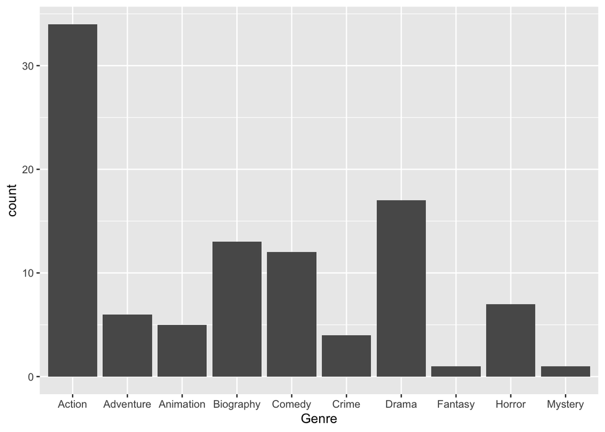

  ```r
  movies %>%
    ggplot() +
    geom_bar(mapping = aes(x = Genre))
  ```

- Which genre is most profitable in terms of average gross earnings?

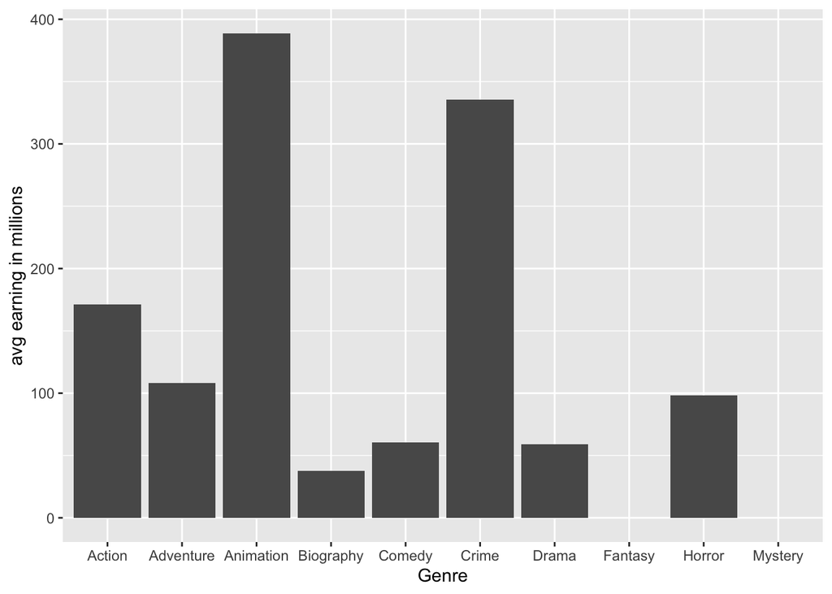

  ```r
  movies %>%
    group_by(Genre) %>%
    summarise(avg_earning = mean(Gross_Earning_in_Mil, na.rm=TRUE)) %>%
    ggplot() +
      geom_col(mapping = aes(x = Genre, y = avg_earning)) +
      labs(y = "avg earning in millions")
  ```

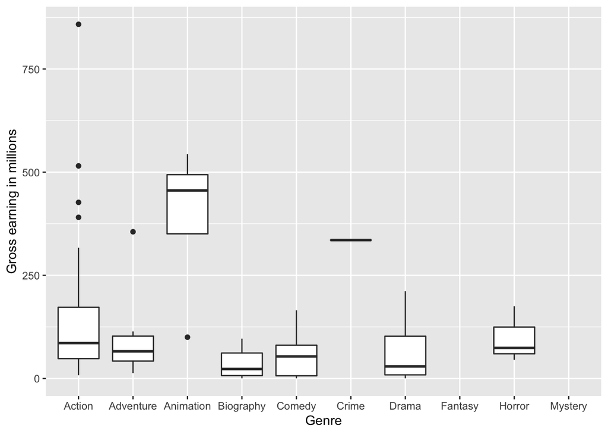

  ```r
  ggplot(data = movies) +
    geom_boxplot(mapping = aes(x = Genre, y = Gross_Earning_in_Mil)) +
    labs(y = "Gross earning in millions")
  ```

- Is there a relationship between gross earning and rating? Find the best selling movie (by gross earning) in each genre

  ```r
  library("ggrepel")
  (best_in_genre <- movies %>%
      group_by(Genre) %>%
      filter(row_number(desc(Gross_Earning_in_Mil)) == 1))
  ```

  ```
  ## # A tibble: 8 × 11
  ## # Groups:   Genre [8]
  ##    Rank Title Description Runtime Genre Rating Metascore  Votes Gross_Earning_i…
  ##   <int> <chr> <chr>         <dbl> <chr>  <dbl>     <dbl>  <dbl>            <dbl>
  ## 1     1 Kniv… "\nA detec…     130 Come…    7.9        82 539726            165.
  ## 2     4 Joker "\nIn Goth…     122 Crime    8.4        59     NA            335.
  ## 3     7 Aven… "\nAfter t…     181 Acti…    8.4        78 950476            858.
  ## 4    12 It C… "\nTwenty-…     169 Drama    6.5        58 232537            212.
  ## 5    22 Rock… "\nA music…     121 Biog…    7.3        69 159413             96.4
  ## 6    26 Us    "\nA famil…     116 Horr…    6.8        73 259098            175.
  ## 7    43 Alad… "\nA kind-…     128 Adve…    6.9        40 246013            356.
  ## 8    57 The … "\nAfter t…     118 Anim…    6.8        55 227563            544.
  ## # … with 2 more variables: Director <chr>, Actor <chr>
  ```

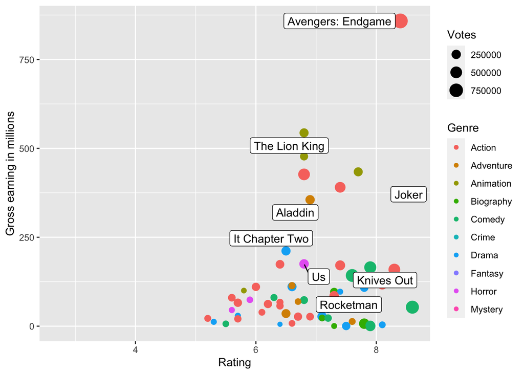

  ```r
  ggplot(movies, mapping = aes(x = Rating, y = Gross_Earning_in_Mil)) +
    geom_point(mapping = aes(size = Votes, color = Genre)) +
    ggrepel::geom_label_repel(aes(label = Title), data = best_in_genre) +
    labs(y = "Gross earning in millions")
  ```

## RSelenium Example: FCC’s television broadcast signal strength

Many websites dynamically pull data from databases using JavasScript and JQuery that make them difficult to scrape.

The FCC’s [dtvmaps webpage](https://www.fcc.gov/media/engineering/dtvmaps) has a simple form in which you enter a zip code and it gives you the available local TV stations in that zip code and their signal strength.

[figure not shown]

You’ll also notice the URL stays fixed with different zip codes.

### Why RSelenium

- *RSelenium* loads the page that we want to scrape and download the HTML from that page.
  - particularly useful when scraping something behind a login
  - simulate human behavior on a website (e.g., mouse clicking)
- *rvest* provides typical scraping tools

```r
rm(list = ls()) # clean-up workspace
library("RSelenium")
library("tidyverse")
library("rvest")
```

### Open up a browser

```r
rD <- rsDriver(browser="firefox", port=sample(1:7360L, 1), verbose=F)
remDr <- rD[["client"]]
```

Open a webpage

```r
remDr$navigate("https://www.fcc.gov/media/engineering/dtvmaps")
```

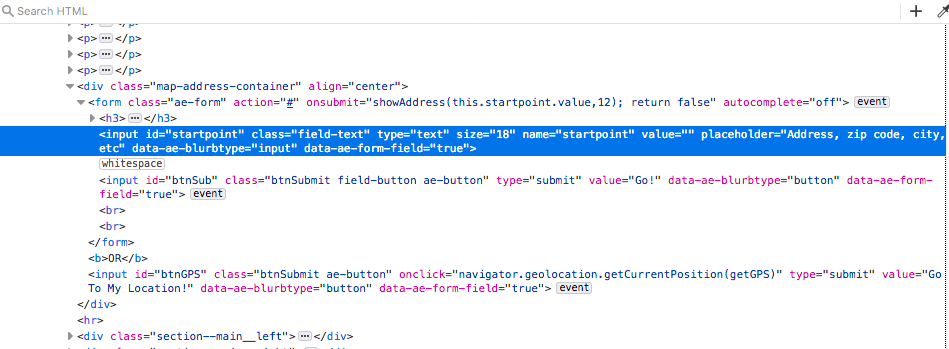

We want to send a string of text (zip code) into the form.

```r
zip <- "70118"
# remDr$findElement(using = "id", value = "startpoint")$clearElement()
remDr$findElement(using = "id", value = "startpoint")$sendKeysToElement(list(zip))
# other possible ("xpath", "css selector", "id", "name", "tag name", "class name", "link text", "partial link text")
```

Click on the button `Go!`

```r
remDr$findElements("id", "btnSub")[[1]]$clickElement()
```

### Extract data from HTML

- save HTML to an object
- use rvest for the rest

```r
Sys.sleep(5) # give the page time to fully load, in seconds
html <- remDr$getPageSource()[[1]]
# important to close the client
remDr$close()

signals <- read_html(html) %>%
  html_nodes("table.tbl_mapReception") %>% # extract table nodes with class = "tbl_mapReception"
  .[3] %>% # keep the third of these tables
  .[[1]] %>% # keep the first element of this list
  html_table(fill=T) # have rvest turn it into a dataframe
signals
```

```
## # A tibble: 39 × 6
##    Callsign                       Callsign   Network   `Ch#`   Band   IA
##    <chr>                          <chr>      <chr>     <chr>   <chr>  <chr>
##  1 "Click on callsign for detail" "Click on… "Click o… "Click… "Clic…  <NA>
##  2 ""                             "WWL-TV"   "CBS"     "4"     "UHF"  "RThis st…
##  3 ""                             ""         ""        ""      ""     ""
##  4 ""                             "WUPL"     "MYNE"    "54"    "UHF"  "RThis st…
##  5 ""                             ""         ""        ""      ""     ""
##  6 ""                             "WVUE-DT"  "FOX"     "8"     "UHF"  ""
##  7 ""                             ""         ""        ""      ""     ""
##  8 ""                             "WPXL-TV"  "ION"     "49"    "UHF"  "RThis st…
##  9 ""                             ""         ""        ""      ""     ""
## 10 ""                             "WHNO"     "IND"     "20"    "UHF"  ""
## # … with 29 more rows
```

More formatting on signals

```r
names(signals) <- c("rm", "callsign", "network", "ch_num", "band", "rm2") # rename columns

signals <- signals %>%
  slice(2:n()) %>% # drop unnecessary first row
  filter(callsign != "") %>% # drop blank rows
  select(callsign:band) # drop unnecessary columns
signals
```

```
## # A tibble: 19 × 4
##    callsign network ch_num band
##    <chr>    <chr>   <chr>  <chr>
##  1 WWL-TV   "CBS"   "4"    UHF
##  2 WUPL     "MYNE"  "54"   UHF
##  3 WVUE-DT  "FOX"   "8"    UHF
##  4 WPXL-TV  "ION"   "49"   UHF
##  5 WHNO     "IND"   "20"   UHF
##  6 WGNO     "ABC"   "26"   UHF
##  7 WDSU     "NBC"   "6"    UHF
##  8 WNOL-TV  "CW"    "38"   UHF
##  9 WYES-TV  "PBS"   "12"   Hi-V
## 10 WTNO-LP  ""      ""     UHF
## 11 WLAE-TV  "PBS"   "32"   UHF
## 12 KNOV-CD  ""      ""     UHF
## 13 WBXN-CD  ""      ""     UHF
## 14 KGLA-DT  "IND"   "42"   UHF
## 15 WBRZ-TV  "ABC"   "2"    Hi-V
## 16 WVLA-TV  "NBC"   "33"   UHF
## 17 WLPB-TV  "PBS"   "27"   UHF
## 18 WGMB-TV  "FOX"   "44"   UHF
## 19 WAFB     "CBS"   "9"    Hi-V
```

Capture all text by clicking on each Callsign

```r
read_html(html) %>%
  html_nodes(".callsign") %>%
  html_attr("onclick")
```

```
##  [1] "getdetail(11158,74192,'WWL-TV Facility ID: 74192 <br>WWL-TV (<a href=https://enterpriseefiling.fcc.gov/dataentry/public/tv/publicFacilityDetails.html?facilityId=74192 target=_new>Licensing</a>) (<a href=https://publicfiles.fcc.gov/tv-profile/74192 target=_new>Public File</a>)<br>City of Lic…
##  [2] "getdetail(11137,13938,'WUPL Facility ID: 13938 <br>WUPL (<a href=https://enterpriseefiling.fcc.gov/dataentry/public/tv/publicFacilityDetails.html?facilityId=13938 target=_new>Licensing</a>) (<a href=https://publicfiles.fcc.gov/tv-profile/13938 target=_new>Public File</a>)<br>City of License…
##  [3] "getdetail(10815,4149,'WVUE-DT Facility ID: 4149 <br>WVUE-DT (<a href=https://enterpriseefiling.fcc.gov/dataentry/public/tv/publicFacilityDetails.html?facilityId=4149 target=_new>Licensing</a>) (<a href=https://publicfiles.fcc.gov/tv-profile/4149 target=_new>Public File</a>)<br>City of Licen…
##  [4] "getdetail(11203,21729,'WPXL-TV Facility ID: 21729 <br>WPXL-TV (<a href=https://enterpriseefiling.fcc.gov/dataentry/public/tv/publicFacilityDetails.html?facilityId=21729 target=_new>Licensing</a>) (<a href=https://publicfiles.fcc.gov/tv-profile/21729 target=_new>Public File</a>)<br>City of L…
##  [5] "getdetail(12228,37106,'WHNO Facility ID: 37106 <br>WHNO (<a href=https://enterpriseefiling.fcc.gov/dataentry/public/tv/publicFacilityDetails.html?facilityId=37106 target=_new>Licensing</a>) (<a href=https://publicfiles.fcc.gov/tv-profile/37106 target=_new>Public File</a>)<br>City of License…
##  [6] "getdetail(11737,72119,'WGNO Facility ID: 72119 <br>WGNO (<a href=https://enterpriseefiling.fcc.gov/dataentry/public/tv/publicFacilityDetails.html?facilityId=72119 target=_new>Licensing</a>) (<a href=https://publicfiles.fcc.gov/tv-profile/72119 target=_new>Public File</a>)<br>City of License…
##  [7] "getdetail(11226,71357,'WDSU Facility ID: 71357 <br>WDSU (<a href=https://enterpriseefiling.fcc.gov/dataentry/public/tv/publicFacilityDetails.html?facilityId=71357 target=_new>Licensing</a>) (<a href=https://publicfiles.fcc.gov/tv-profile/71357 target=_new>Public File</a>)<br>City of License…
##  [8] "getdetail(11738,54280,'WNOL-TV Facility ID: 54280 <br>WNOL-TV (<a href=https://enterpriseefiling.fcc.gov/dataentry/public/tv/publicFacilityDetails.html?facilityId=54280 target=_new>Licensing</a>) (<a href=https://publicfiles.fcc.gov/tv-profile/54280 target=_new>Public File</a>)<br>City of L…
##  [9] "getdetail(11911,25090,'WYES-TV Facility ID: 25090 <br>WYES-TV (<a href=https://enterpriseefiling.fcc.gov/dataentry/public/tv/publicFacilityDetails.html?facilityId=25090 target=_new>Licensing</a>) (<a href=https://publicfiles.fcc.gov/tv-profile/25090 target=_new>Public File</a>)<br>City of L…
## [10] "getdetail(12360,24981,'WTNO-LP Facility ID: 24981 <br>WTNO-LP (<a href=https://enterpriseefiling.fcc.gov/dataentry/public/tv/publicFacilityDetails.html?facilityId=24981 target=_new>Licensing</a>) (<a href=https://publicfiles.fcc.gov/tv-profile/24981 target=_new>Public File</a>)<br>City of L…
## [11] "getdetail(11281,18819,'WLAE-TV Facility ID: 18819 <br>WLAE-TV (<a href=https://enterpriseefiling.fcc.gov/dataentry/public/tv/publicFacilityDetails.html?facilityId=18819 target=_new>Licensing</a>) (<a href=https://publicfiles.fcc.gov/tv-profile/18819 target=_new>Public File</a>)<br>City of L…
## [12] "getdetail(12467,64048,'KNOV-CD Facility ID: 64048 <br>KNOV-CD (<a href=https://enterpriseefiling.fcc.gov/dataentry/public/tv/publicFacilityDetails.html?facilityId=64048 target=_new>Licensing</a>) (<a href=https://publicfiles.fcc.gov/tv-profile/64048 target=_new>Public File</a>)<br>City of L…
## [13] "getdetail(12443,70419,'WBXN-CD Facility ID: 70419 <br>WBXN-CD (<a href=https://enterpriseefiling.fcc.gov/dataentry/public/tv/publicFacilityDetails.html?facilityId=70419 target=_new>Licensing</a>) (<a href=https://publicfiles.fcc.gov/tv-profile/70419 target=_new>Public File</a>)<br>City of L…
## [14] "getdetail(10726,83945,'KGLA-DT Facility ID: 83945 <br>KGLA-DT (<a href=https://enterpriseefiling.fcc.gov/dataentry/public/tv/publicFacilityDetails.html?facilityId=83945 target=_new>Licensing</a>) (<a href=https://publicfiles.fcc.gov/tv-profile/83945 target=_new>Public File</a>)<br>City of L…
## [15] "getdetail(11797,38616,'WBRZ-TV Facility ID: 38616 <br>WBRZ-TV (<a href=https://enterpriseefiling.fcc.gov/dataentry/public/tv/publicFacilityDetails.html?facilityId=38616 target=_new>Licensing</a>) (<a href=https://publicfiles.fcc.gov/tv-profile/38616 target=_new>Public File</a>)<br>City of L…
## [16] "getdetail(12198,70021,'WVLA-TV Facility ID: 70021 <br>WVLA-TV (<a href=https://enterpriseefiling.fcc.gov/dataentry/public/tv/publicFacilityDetails.html?facilityId=70021 target=_new>Licensing</a>) (<a href=https://publicfiles.fcc.gov/tv-profile/70021 target=_new>Public File</a>)<br>City of L…
## [17] "getdetail(10829,38586,'WLPB-TV Facility ID: 38586 <br>WLPB-TV (<a href=https://enterpriseefiling.fcc.gov/dataentry/public/tv/publicFacilityDetails.html?facilityId=38586 target=_new>Licensing</a>) (<a href=https://publicfiles.fcc.gov/tv-profile/38586 target=_new>Public File</a>)<br>City of L…
## [18] "getdetail(11101,12520,'WGMB-TV Facility ID: 12520 <br>WGMB-TV (<a href=https://enterpriseefiling.fcc.gov/dataentry/public/tv/publicFacilityDetails.html?facilityId=12520 target=_new>Licensing</a>) (<a href=https://publicfiles.fcc.gov/tv-profile/12520 target=_new>Public File</a>)<br>City of L…
## [19] "getdetail(11961,589,'WAFB Facility ID: 589 <br>WAFB (<a href=https://enterpriseefiling.fcc.gov/dataentry/public/tv/publicFacilityDetails.html?facilityId=589 target=_new>Licensing</a>) (<a href=https://publicfiles.fcc.gov/tv-profile/589 target=_new>Public File</a>)<br>City of License: BATON …
```

Extract signal by string operations

```r
strength <- read_html(html) %>%
  html_nodes(".callsign") %>%
  html_attr("onclick") %>%
  str_extract("(?<=RX Strength: )\\s*\\-*[0-9.]+")

# (?<=…)  is a special regex expression for positive lookbehind

signals <- cbind(signals, strength)
signals
```

```
##    callsign network ch_num band strength
## 1    WWL-TV     CBS      4  UHF      115
## 2      WUPL    MYNE     54  UHF      114
## 3   WVUE-DT     FOX      8  UHF      112
## 4   WPXL-TV     ION     49  UHF      111
## 5      WHNO     IND     20  UHF      111
## 6      WGNO     ABC     26  UHF      111
## 7      WDSU     NBC      6  UHF      111
## 8   WNOL-TV      CW     38  UHF      110
## 9   WYES-TV     PBS     12 Hi-V      102
## 10  WTNO-LP                 UHF      106
## 11  WLAE-TV     PBS     32  UHF      104
## 12  KNOV-CD                 UHF      101
## 13  WBXN-CD                 UHF       98
## 14  KGLA-DT     IND     42  UHF       93
## 15  WBRZ-TV     ABC      2 Hi-V       45
## 16  WVLA-TV     NBC     33  UHF       46
## 17  WLPB-TV     PBS     27  UHF       44
## 18  WGMB-TV     FOX     44  UHF       43
## 19     WAFB     CBS      9 Hi-V       37
```